# Relatório Analítico — Violência contra a Mulher no Distrito Federal

Ocorrências da Lei Maria da Penha atendidas pela PMDF e notificações do SINAN

Autores

Arthur Virgílio

Emanuela Araújo

Felipe Teodoro

José Carvalho

Lucas Petry

Data de Publicação

18/10/2026

# Sumário executivo

- **12.123 ocorrências** da Lei Maria da Penha atendidas pela PMDF em 2024 compõem a base. As formas de violência e os fatores de contexto foram extraídos das narrativas policiais e indicam o que o policial **registrou**, não necessariamente tudo o que ocorreu.
- **O fim de semana concentra a demanda.** Sábados e domingos têm, em média, 1,65 vezes mais ocorrências por dia que os dias úteis, e 27,6% dos atendimentos ocorrem entre 20h e 23h, contra 16,7% esperados se o horário fosse indiferente.
- **Feriados em dias úteis elevam a demanda.** Tiveram 51% mais ocorrências que o mesmo dia da semana nas semanas vizinhas, excesso semelhante ao do fim de semana. Feriados que caem no sábado ou no domingo e datas comemorativas sem feriado (Dia das Mães, Dia dos Namorados, vésperas de Natal e Ano-Novo) não diferiram do padrão.
- **A violência registrada é múltipla.** A violência física aparece em 40,3% das ocorrências, a psicológica em 34,6% e a patrimonial em 29,2%. Em 35,6% dos registros há duas ou mais formas simultâneas.
- **Parte da associação entre álcool e violência é efeito do texto.** Narrativas que citam álcool são mais longas (mediana de 161 contra 104 palavras). Ajustada pelo tamanho do histórico, a razão de prevalência entre álcool e violência física cai de 1,39 para 1,04.
- **A demanda é concentrada no espaço, mas os mapas são parciais.** Entre as ocorrências com coordenada válida (53,3% do total), 16,6% das células de 500 m concentram metade dos registros. A cobertura de GPS, porém, varia de 4% a 80% entre as RAs.
- **O SINAN amplia o retrato.** As notificações de saúde incluem violência sexual contra meninas, ausente da demanda policial, e violência física contra mulheres adultas, em geral por parceiro. O padrão de fim de semana e noite se repete nas duas fontes, e o vínculo íntimo é o fator mais associado à violência de repetição (Seção 8).
- **Há uma lacuna de registro em setembro.** Não há nenhuma ocorrência registrada no sistema entre 06/09 e 16/09. A queda de setembro é, portanto, um artefato de registro, e não uma redução da violência.

# 1 Dados, definições e qualidade

## 1.1 Unidade de análise e leitura dos indicadores

A unidade de análise é a **ocorrência policial**, não a vítima. Uma mesma mulher pode figurar em vários registros, e episódios não comunicados à PMDF não estão na base. Os resultados descrevem, portanto, a **demanda que chegou ao policiamento ostensivo**, e não a prevalência da violência no Distrito Federal.

As formas de violência e os fatores de contexto foram extraídos do histórico por regras de processamento de linguagem natural, com tratamento de negação (“não agrediu”, “não possui medida protetiva”). Uma flag positiva significa que o termo foi **mencionado** na narrativa; uma flag negativa significa “não identificado”, e não “ausente”. As regras e suas limitações estão descritas na metodologia do projeto.

## 1.2 Qualidade da base

Tabela 1: Indicadores de qualidade da base PMDF

| Indicador | Valor | Observação |
| --- | --- | --- |
| Ocorrências | 12.123 | Data do fato entre 01/01 e 31/12/2024 |
| Registro no mesmo dia do fato | 53,4% | 179 registradas mais de 30 dias depois |
| Coordenada utilizável (grade 500 m) | 53,3% | Demais na coordenada-padrão do sistema ou sem coordenada |
| Horário em minuto cheio (hh:00) | 7,1% | 1,7% esperado; 72 registros às 0h00 |
| Narrativas idênticas longas (≥ 30 palavras) | 23 | Provável duplo registro do mesmo atendimento |
| Textos curtos padronizados | 99 | Narrativas repetidas sem descrição do fato |
| Dias sem nenhum registro no sistema | 11 | 06/09 a 16/09 |

Três pontos condicionam toda a leitura a seguir:

1. **Lacuna de registro em setembro.** O número da ocorrência codifica a data de registro. Entre 06/09 e 16/09 de 2024 não há nenhum registro, e os fatos desse período aparecem depois, em volume reduzido. Setembro teve 22,6 ocorrências por dia, contra 34,1 nos demais meses. A falha de sistema ou de extração precisa ser confirmada com a PMDF; até lá, setembro não deve ser lido como queda da violência.
2. **Georreferenciamento parcial e desigual.** Só 53,3% das ocorrências têm coordenada utilizável, e a proporção varia de 4% (Vicente Pires) a 80% (Samambaia) entre as RAs com mais de 200 ocorrências (Figura 8). Os mapas mostram onde a posição da viatura foi registrada, e não toda a demanda.
3. **Duplicidades.** Cerca de 1,0% dos registros são narrativas repetidas. O efeito máximo sobre qualquer proporção deste relatório é de cerca de um ponto percentual.

# 2 Padrões temporais

## 2.1 Ao longo do ano

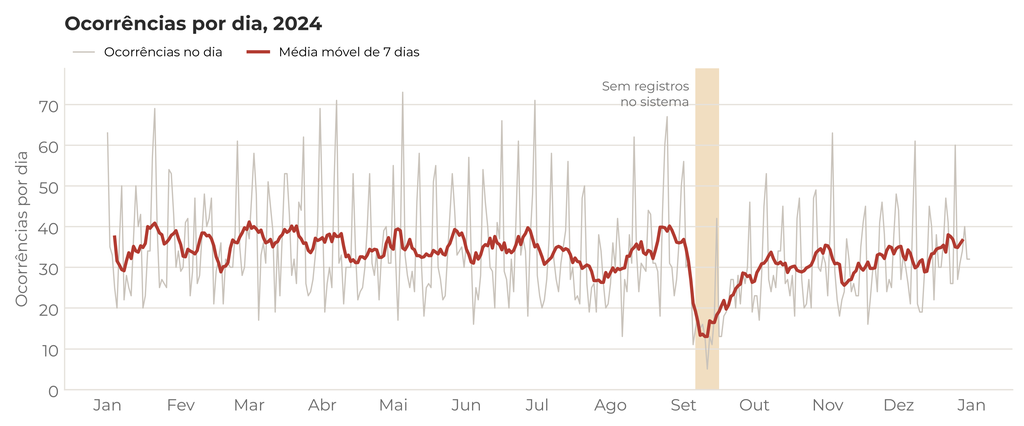

Figura 1: Ocorrências por dia em 2024. A faixa marca o período sem nenhum registro no sistema.

A distribuição mensal **não é uniforme**, mesmo considerando o número de dias de cada mês (qui-quadrado = 170,5; p < 0,001). Março teve o maior volume relativo (16% acima do esperado). Setembro teve o menor, explicado pela lacuna de registro. Sem setembro, a heterogeneidade persiste (p < 0,001), mas com amplitude menor: os demais meses variam entre −9% e +16% em relação ao esperado. Com um único ano de dados, não é possível separar sazonalidade de flutuação específica de 2024.

## 2.2 Dias da semana e horário

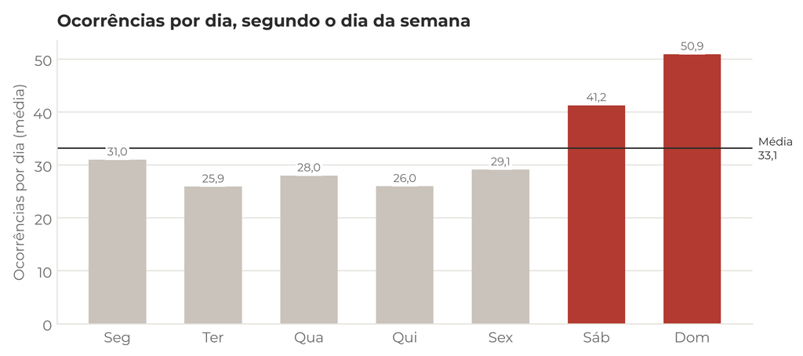

Figura 2: Média de ocorrências por dia, segundo o dia da semana (2024 tem 53 segundas e terças).

Sábado e domingo reúnem 39,5% das ocorrências, contra 28,4% dos dias do ano. Por dia, a demanda do fim de semana é 1,65 vezes a dos dias úteis (IC 95%: 1,59–1,71). O domingo é o dia de maior demanda (50,9 ocorrências por dia).

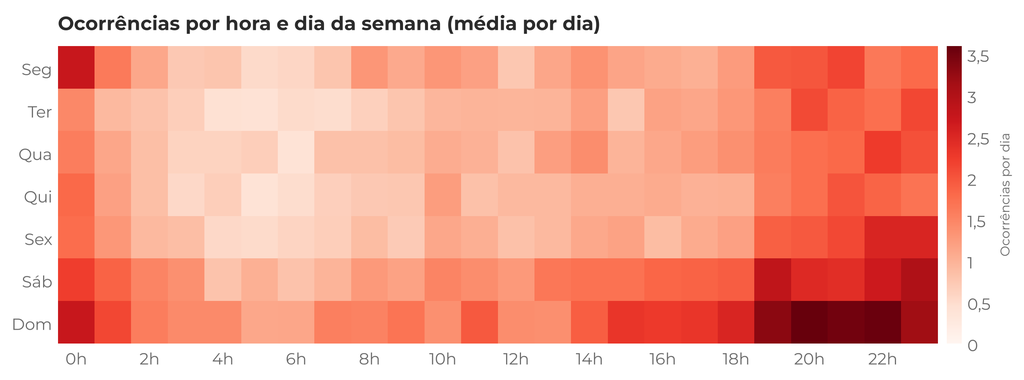

Figura 3: Média de ocorrências por dia em cada hora e dia da semana.

O horário de maior demanda é 23h, e a faixa das 20h às 23h concentra 27,6% das ocorrências, contra 16,7% esperados sob distribuição uniforme. A Figura 3 mostra onde essa demanda se acumula:

- **Noite de domingo.** É o pico da semana: das 19h às 22h, cada hora teve em média 3,3 a 3,6 ocorrências por domingo. A noite de sábado vem em seguida.
- **Madrugada.** Entre 0h e 4h, a madrugada de domingo é a mais movimentada da semana (1,9 ocorrências por hora, contra 1,1 nos dias úteis).
- **Virada de domingo para segunda.** A 0h de segunda-feira (2,7) se iguala à de domingo, como continuação da noite de domingo.

O padrão é coerente com os períodos de maior convívio doméstico.

Há arredondamento de horário: 7,1% dos registros terminam em minuto cheio, e 72 estão às 0h00 exatas, o que sugere uso desse horário como valor-padrão. Esses registros são 9,6% da hora 0h, que fica levemente inflada; nas demais faixas o efeito é desprezível.

## 2.3 Feriados e datas comemorativas

Cada data foi comparada com a média do mesmo dia da semana nas quatro semanas anteriores e posteriores, o que controla o efeito do dia da semana e da época do ano. Os dias de 05/09 a 30/09, afetados pela lacuna de registro, foram excluídos da comparação.

Tabela 2: Ocorrências em feriados e datas comemorativas de 2024, comparadas ao mesmo dia da semana nas semanas vizinhas

| Data | Data festiva | Tipo | Observado | Esperado | Razão |
| --- | --- | --- | --- | --- | --- |
| 01/01 (seg) | Confraternização Universal | Feriado | 63 | 37,0 | 1,70 |
| 12/02 (seg) | Carnaval | Feriado | 40 | 36,5 | 1,10 |
| 13/02 (ter) | Carnaval | Feriado | 42 | 25,0 | 1,68 |
| 29/03 (sex) | Paixão de Cristo | Feriado | 33 | 33,8 | 0,98 |
| 21/04 (dom) | Tiradentes / Aniversário de Brasília | Feriado | 53 | 60,1 | 0,88 |
| 01/05 (qua) | Dia do Trabalho | Feriado | 55 | 26,4 | 2,09 |
| 30/05 (qui) | Corpus Christi | Feriado | 35 | 25,2 | 1,39 |
| 07/09 (sáb) | Independência | Feriado | 18 | 46,0 | excluída |
| 12/10 (sáb) | Nossa Senhora Aparecida | Feriado | 34 | 42,8 | 0,80 |
| 02/11 (sáb) | Finados | Feriado | 39 | 42,2 | 0,92 |
| 15/11 (sex) | Proclamação da República | Feriado | 35 | 24,6 | 1,42 |
| 20/11 (qua) | Consciência Negra | Feriado | 29 | 25,1 | 1,15 |
| 30/11 (sáb) | Dia do Evangélico (DF) | Feriado | 48 | 41,0 | 1,17 |
| 25/12 (qua) | Natal | Feriado | 60 | 26,5 | 2,26 |
| 12/05 (dom) | Dia das Mães | Comemorativa | 58 | 53,8 | 1,08 |
| 12/06 (qua) | Dia dos Namorados | Comemorativa | 29 | 25,5 | 1,14 |
| 24/12 (ter) | Véspera de Natal | Comemorativa | 26 | 28,5 | 0,91 |
| 31/12 (ter) | Véspera de Ano-Novo | Comemorativa | 32 | 30,0 | 1,07 |

Independência caiu no período da lacuna de registro e ficou fora do total. No conjunto, os feriados tiveram 566 ocorrências, contra 446 esperadas, uma razão de 1,27 (IC 95%: 1,17–1,38). O efeito depende do dia em que o feriado cai:

- **Feriados em dias úteis** tiveram razão de 1,51 (IC 95%: 1,36–1,66). O excesso é próximo da razão entre fim de semana e dias úteis (1,65): o dia útil de folga se comporta como um domingo. Os maiores excessos foram no Natal, no Dia do Trabalho e na Confraternização Universal.
- **Feriados no fim de semana** não diferiram do esperado (razão de 0,94; IC 95%: 0,80–1,09), porque não acrescentam tempo livre.
- **Datas comemorativas sem feriado** também não diferiram do esperado (razão de 1,05; IC 95%: 0,89–1,24).

O conjunto sustenta a leitura de que **o tempo de convívio, mais que a data em si, eleva a demanda**.

# 3 Formas de violência

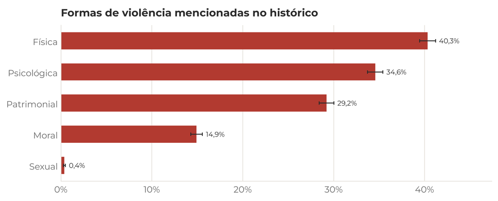

Figura 4: Proporção de ocorrências com menção a cada forma de violência (art. 7º da Lei nº 11.340/2006), com IC 95%.

Ao menos uma forma de violência foi identificada em 66,3% das ocorrências. As formas **se sobrepõem**: 35,6% dos registros mencionam duas ou mais, e a combinação mais frequente é física com psicológica (1.992 ocorrências, 16,4% do total).

A violência sexual (0,4%) é residual nos registros da PMDF, em contraste com o SINAN (Seção 9). A violência sexual raramente motiva o acionamento da polícia ostensiva e tende a ser relatada em outros canais, como serviços de saúde e delegacias especializadas. A baixa frequência é, portanto, um traço do canal de registro, e não um indicador da sua ocorrência.

# 4 Fatores de contexto e de risco

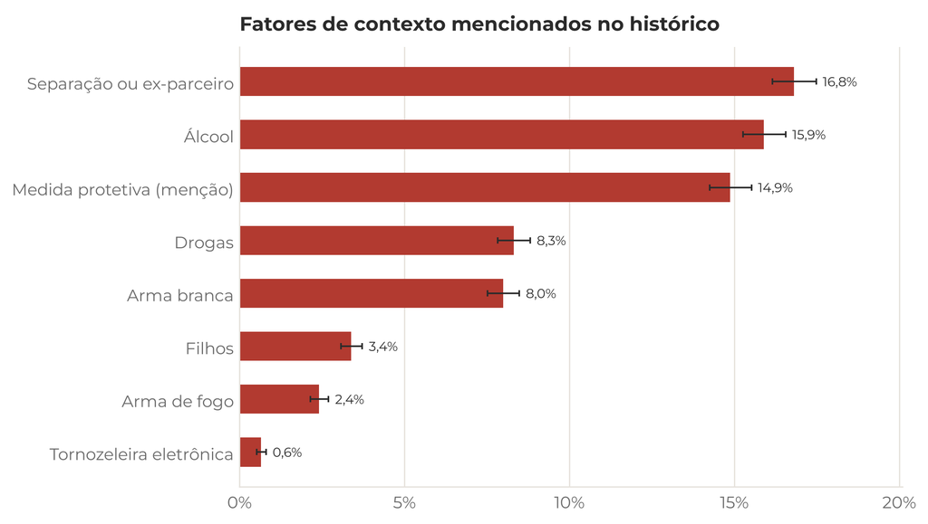

Figura 5: Proporção de ocorrências com menção a cada fator de contexto, com IC 95%.

41,9% das ocorrências mencionam ao menos um entre álcool, drogas, medida protetiva e separação. Duas ressalvas de leitura:

- **Medida protetiva** indica que a medida foi **mencionada** (vigente, solicitada ou descumprida). Só 13,1% dessas narrativas usam o termo “descumprimento”, e a flag não deve ser lida como taxa de descumprimento.
- **Álcool** reflete a percepção registrada pelo policial, não uma constatação clínica.

## 4.1 Associações e o efeito do tamanho do texto

Fatores como o álcool tornam a narrativa mais longa, e narrativas longas mencionam mais termos de qualquer categoria. Comparar diretamente quem tem e quem não tem a flag mistura a associação real com esse **viés de detecção**. Por isso, as razões de prevalência foram calculadas em duas versões: bruta e ajustada pelo tamanho do histórico (Mantel-Haenszel, estratos por decis do número de palavras).

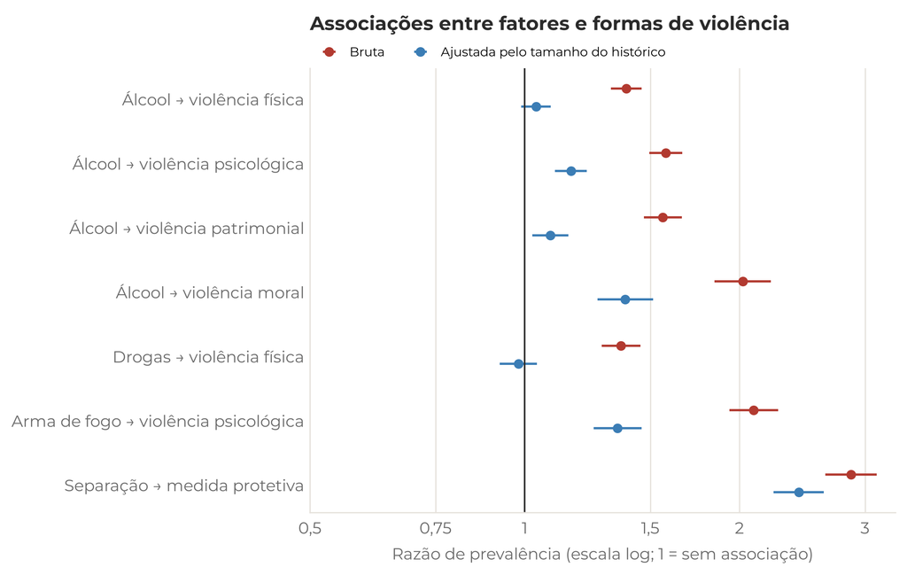

Figura 6: Razões de prevalência (IC 95%) brutas e ajustadas pelo tamanho do histórico.

Tabela 3: Razões de prevalência brutas e ajustadas pelo tamanho do histórico

| Associação | RP bruta (IC 95%) | RP ajustada (IC 95%) |
| --- | --- | --- |
| Álcool → violência física | 1,39 (1,32–1,46) | 1,04 (0,99–1,09) |
| Álcool → violência psicológica | 1,58 (1,49–1,66) | 1,16 (1,10–1,22) |
| Álcool → violência patrimonial | 1,56 (1,47–1,66) | 1,09 (1,02–1,15) |
| Álcool → violência moral | 2,02 (1,85–2,21) | 1,38 (1,26–1,51) |
| Drogas → violência física | 1,36 (1,28–1,45) | 0,98 (0,92–1,04) |
| Arma de fogo → violência psicológica | 2,09 (1,94–2,27) | 1,35 (1,25–1,46) |
| Separação → medida protetiva | 2,87 (2,64–3,11) | 2,42 (2,23–2,63) |

O ajuste muda a conclusão para o álcool:

- **Violência física.** A associação bruta com o álcool (RP = 1,39; IC 95%: 1,32–1,46) praticamente desaparece após o ajuste (RP = 1,04; IC 95%: 0,99–1,09). O mesmo ocorre com as drogas (RP ajustada = 0,98; IC 95%: 0,92–1,04). Bandiera-Paiva et al. (2026), com dados estruturados do SINAN, encontraram 1,17 para o álcool. O valor bruto da PMDF superestima a associação.
- **Violências moral, psicológica e patrimonial.** Permanecem associadas ao álcool após o ajuste, mas atenuadas: RP ajustadas de 1,38, 1,16 e 1,09, respectivamente. A ofensa verbal e a ameaça sob efeito de álcool são um padrão plausível, mas as flags não distinguem quem bebeu.
- **Arma de fogo e violência psicológica.** A associação cai, mas persiste (RP ajustada = 1,35; IC 95%: 1,25–1,46), coerente com o uso da arma como instrumento de ameaça.
- **Separação e medida protetiva.** É a associação mais forte e a menos sensível ao ajuste (RP ajustada = 2,42; IC 95%: 2,23–2,63), coerente com o uso da medida protetiva após o rompimento.

O ajuste pode ser conservador: se episódios mais graves geram relatos mais longos, ele remove também parte da associação real. As estimativas bruta e ajustada devem ser lidas em conjunto, como uma faixa plausível. Todas as associações são transversais e não autorizam leitura causal.

## 4.2 Álcool e medida protetiva no tempo

- **Álcool.** É mais frequente no fim de semana (RP = 1,21; IC 95%: 1,12–1,32) e entre 20h e 23h (RP = 1,28; IC 95%: 1,17–1,39). A variação entre os dias da semana é estatisticamente significativa (p < 0,001), mas pequena (V de Cramér = 0,04).
- **Medida protetiva.** As menções **não** se concentram no fim de semana: só 36,7% delas ocorrem em sábados e domingos, e a proporção não varia entre os dias (p = 0,121). São mais frequentes no horário comercial, das 8h às 17h (RP = 1,24; IC 95%: 1,14–1,35), possivelmente pela procura ativa da vítima por apoio durante o dia.

# 5 Desfecho do atendimento e local

O desfecho foi inferido da narrativa:

- **encaminhamento à delegacia:** 62,1%;
- **resolução no local** (orientação ou acordo): 10,4%;
- **não identificado:** 27,5%. Essa parcela limita a análise do desfecho.

O encaminhamento é mais frequente quando há violência física (RP = 1,75; IC 95%: 1,71–1,80) ou arma branca (RP = 1,57; IC 95%: 1,54–1,61).

Quanto ao local, obtido do endereço:

- **casas:** 63,4% das ocorrências;
- **apartamentos:** 10,0%;
- **via pública:** 5,0%;
- **comércio:** 1,0%;
- **sem identificação:** 20,7%, porque o endereço digitado não permite classificar o local.

# 6 Repetição de chamados no mesmo endereço

A repetição foi medida por uma chave textual (RA, quadra e complemento), e não pela identificação de pessoas. Ela indica **demanda recorrente sobre um local**, e não necessariamente revitimização da mesma mulher.

Tabela 4: Endereços residenciais com mais de uma ocorrência em 2024

| Ocorrências no endereço | Endereços |
| --- | --- |
| 2 | 356 |
| 3 | 51 |
| 4 | 24 |
| 5 | 6 |
| 6 | 1 |

438 endereços residenciais tiveram mais de uma ocorrência no ano, a maioria (81,3%) com exatamente duas. Duas ressalvas impedem ler esse número como “lares com violência recorrente”:

- **A chave não identifica a pessoa.** Quase todos esses endereços têm número de casa ou apartamento, mas a chave pode agrupar residências distintas quando o endereço omite o conjunto ou o lote. Além disso, moradoras diferentes podem ter ocupado o mesmo imóvel.
- **Parte é duplo registro.** 10,4% dos intervalos entre chamados consecutivos são menores que um dia, o que sugere duplo registro do mesmo atendimento.

Excluídos os intervalos menores que um dia, a mediana entre chamados foi de 68 dias, e 28,3% dos retornos ocorreram em até 30 dias.

A literatura mostra que a repetição de chamados em um mesmo endereço é frequente e prediz novos episódios (FARRELL; PEASE, 1993; KUMAR et al., 2024). Os dados de 2024 são compatíveis com esse padrão. Medir a revitimização, porém, exige identificar a vítima, o que a base não permite.

# 7 Distribuição espacial

## 7.1 Concentração

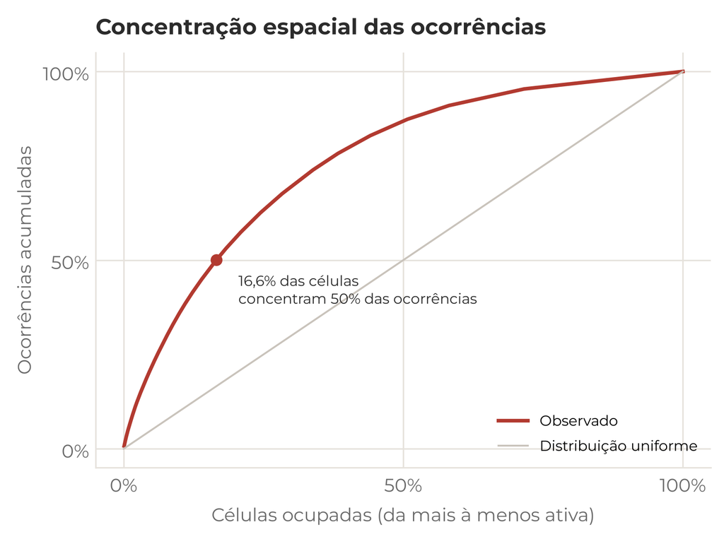

Figura 7: Curva de concentração das ocorrências nas células de 500 m com ao menos um registro.

As ocorrências georreferenciadas distribuem-se por 1.054 células de 500 m. Metade delas está em 175 células (16,6%), e os 5% de células mais ativas reúnem 21,8% dos registros (índice de Gini = 0,53).

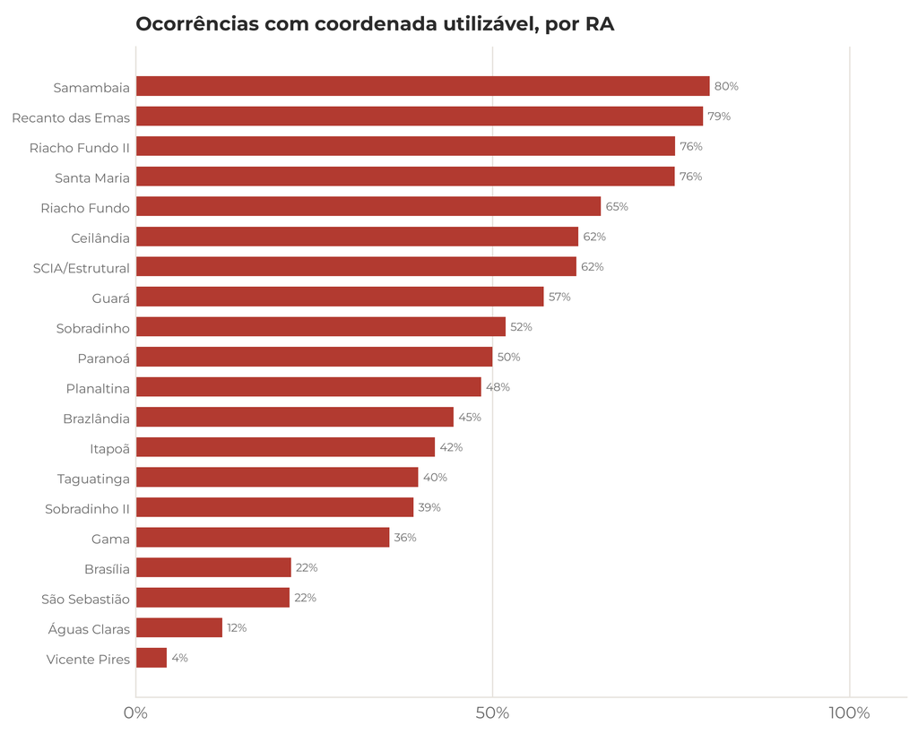

Figura 8: Proporção de ocorrências com coordenada utilizável, por RA (RAs com mais de 200 ocorrências).

**A concentração deve ser lida junto com a cobertura.** Uma RA com baixa cobertura de GPS aparece “fria” no mapa mesmo com muitas ocorrências. Comparações entre RAs devem usar as contagens por RA, que são completas, e não a grade.

A concentração, porém, não é só efeito da cobertura. Restrita às 7 RAs com ao menos 60% das ocorrências georreferenciadas, ela persiste com intensidade um pouco menor: 21,4% das células concentram metade dos registros (Gini = 0,44).

## 7.2 Proximidade dos batalhões

Para verificar se as áreas de maior demanda ficam distantes das unidades da PMDF, calculou-se a distância do centro de cada célula ao batalhão mais próximo.

- **No conjunto das células,** não há relação monotônica entre demanda e distância (correlação de Spearman = −0,05; p = 0,124).
- **No topo da distribuição,** as 5% de células mais ativas estão, em mediana, mais distantes de um batalhão: 3,6 km, contra 2,5 km nas demais (Mann-Whitney, p < 0,001). 15 dessas 53 células ficam a mais de 5 km, principalmente em Recanto das Emas, Samambaia.

O resultado identifica um conjunto pequeno de áreas de alta demanda relativamente afastadas das sedes, candidatas a uma análise de tempo de resposta. Não demonstra “vácuo de policiamento”: a sede do batalhão não é o ponto de partida das viaturas, que patrulham em movimento, e não foram usados dados de população nem de tempo de atendimento.

## 7.3 Comparação com os feminicídios por RA

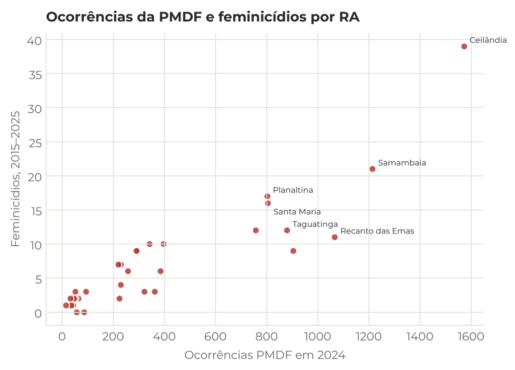

Figura 9: Ocorrências PMDF (2024) e feminicídios consumados (2015–2025) por RA.

As RAs com mais ocorrências na PMDF também concentram mais feminicídios (correlação de Spearman = 0,88; p < 0,001; 31 RAs). A leitura exige cautela:

- **Tamanho da população.** Ambas as contagens crescem com a população da RA, e sem taxas por habitante a correlação reflete, em boa parte, esse tamanho.
- **Períodos e resoluções distintos.** Os feminicídios (230 casos entre 2015 e 2025) não têm coordenadas e cobrem um período diferente do da PMDF.

Os dados indicam **convergência territorial no nível de RA**. Não permitem afirmar que a demanda da PMDF “antecipa” os feminicídios, nem validar a grade de 500 m como preditora deles. Para isso seriam necessárias taxas por população, a localização dos casos e uma série histórica comum.

# 8 Análise exploratória do SINAN

O SINAN (Sistema de Informação de Agravos de Notificação) recebe a ficha de notificação individual de violência interpessoal e autoprovocada, preenchida por serviços de saúde e, desde 2011, de notificação compulsória. Esta seção descreve a base SINAN pelo mesmo roteiro aplicado à PMDF. O recorte é o da integração (Seção 9): mulheres, ocorrência no Distrito Federal (`ID_MN_OCOR = 530010`) e violência não autoprovocada confirmada (`LES_AUTOP = 2`). São 24.648 notificações entre 2010 e 2025, das quais 3.112 em 2024.

A unidade de análise é a **notificação**, não a mulher, e as notificações descrevem a violência que **chegou a um serviço de saúde**. Diferentemente das flags da PMDF, os campos do SINAN são perguntas estruturadas da ficha: “não” e “ignorado” são respostas distintas. Por isso, as proporções a seguir são calculadas entre as respostas válidas (sim ou não), e o peso do ignorado é informado quando relevante.

## 8.1 Qualidade da base

Tabela 5: Indicadores de qualidade da base SINAN

| Indicador | Valor | Observação |
| --- | --- | --- |
| Linhas na exportação recebida | 35.745 | Mulheres, 2010–2025 |
| Notificações na coorte analítica | 24.648 | Ocorrência no DF e violência não autoprovocada |
| Duplicatas exatas | 5 | Idênticas nas 159 colunas |
| Notificação após 30 dias (2024) | 30,8% | Mediana de 3 dias; p90 de 181 dias |
| Data de ocorrência no dia 1 do mês (2024) | 7,4% | Provável data imputada; 3,3% esperados |
| Hora da ocorrência informada (2024) | 36,9% | 6,5% delas às 00:00 |
| Motivação ignorada ou vazia | 47,5% |  |
| Suspeita de álcool ignorada ou vazia | 43,1% |  |
| Escolaridade ignorada ou vazia | 41,3% |  |
| Raça/cor ignorada ou vazia | 5,0% |  |

## 8.2 Série histórica

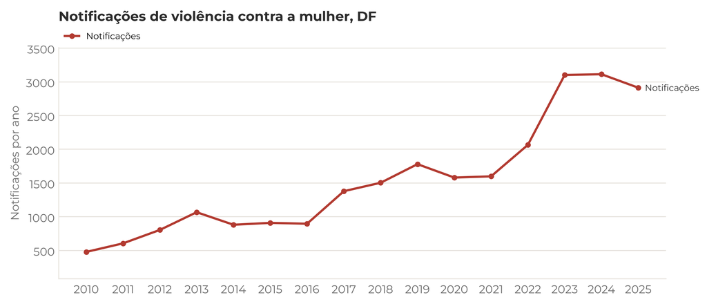

Figura 10: Notificações de violência contra a mulher no SINAN, por ano de ocorrência (coorte analítica). O último ano é preliminar.

As notificações passaram de 476 em 2010 para 3.112 em 2024. A série cresce em degraus, com saltos em 2017 (+54%) e 2023 (+50%) e queda em 2020 (−11%), primeiro ano da pandemia, quando a procura por serviços de saúde caiu. Mudanças desse porte em um ano são mais compatíveis com expansão da rede notificadora e da cultura de notificação do que com variação da violência; a série mede a **atividade de notificação**.

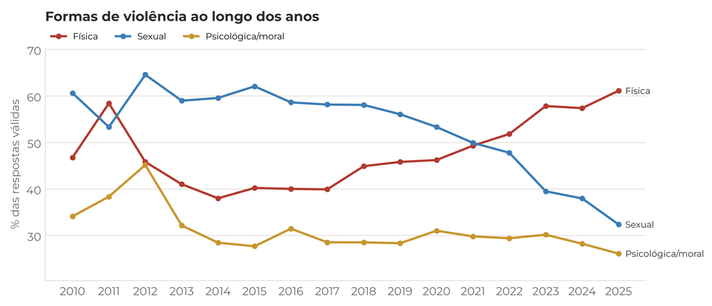

Figura 11: Proporção de notificações com cada forma de violência, por ano (% das respostas válidas).

A composição mudou. A violência sexual, que respondia por 61% das notificações em 2010, caiu para 38% em 2024, enquanto a física subiu de 47% para 57%. O crescimento recente das notificações veio sobretudo da violência física, o que aproxima o perfil do SINAN daquele atendido pela polícia.

## 8.3 Padrões temporais em 2024

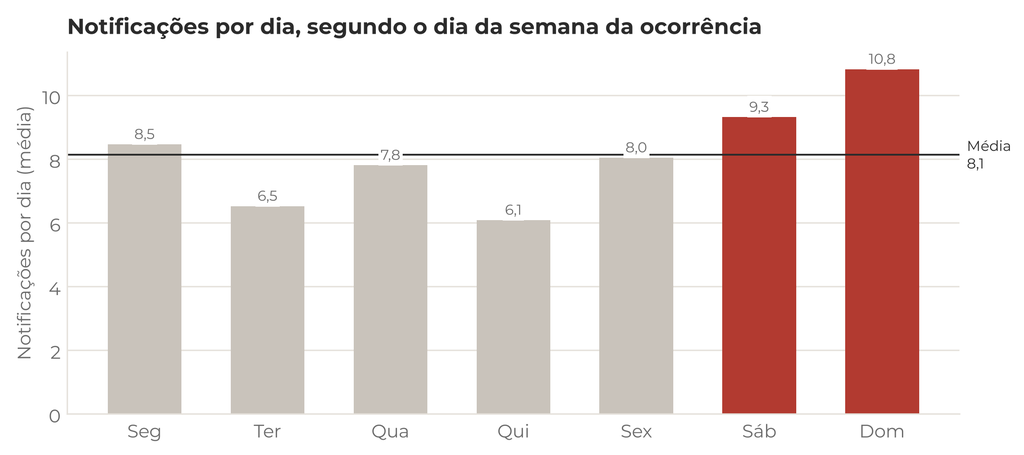

Figura 12: Média de notificações por dia de ocorrência, segundo o dia da semana (datas imputadas excluídas).

O padrão semanal é o mesmo da PMDF. Sábados e domingos têm, em média, 1,36 vezes mais ocorrências por dia que os dias úteis (IC 95%: 1,26–1,47), e o domingo é o dia de maior volume (10,8 por dia). Entre as notificações com hora válida, 27,7% ocorreram entre 20h e 23h, contra 16,7% esperados se o horário fosse indiferente. Duas fontes independentes, com registros feitos por profissionais diferentes, apontam para os mesmos períodos de convívio.

A distribuição mensal não é uniforme (qui-quadrado = 39,5; p < 0,001), com maior volume relativo em setembro (28% acima do esperado). Os feriados em dias úteis, ao contrário da PMDF, não se destacaram (razão de 0,87; IC 95%: 0,63–1,17). Com cerca de oito notificações por dia, porém, o teste tem pouca precisão para efeitos de um dia.

## 8.4 Perfil das vítimas

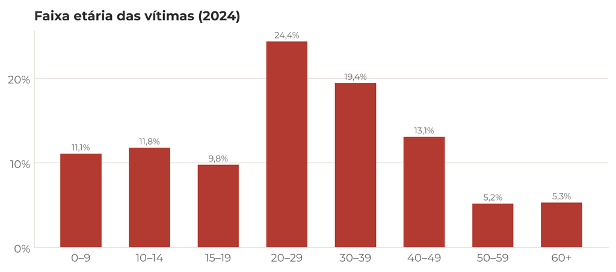

Figura 13: Distribuição das notificações por faixa etária da vítima.

A principal diferença em relação à PMDF é a idade. 28,9% das vítimas notificadas têm menos de 18 anos, e a faixa de 10 a 14 anos sozinha soma 11,8%. A mediana é de 26 anos. Entre as respostas válidas, 75,7% das vítimas são negras (pretas ou pardas), 39,9% estudaram até o ensino fundamental completo e 21,1% têm alguma deficiência ou transtorno.

## 8.5 Formas de violência e meios de agressão

Para aproximar o SINAN do escopo da Lei Maria da Penha, definiu-se um **recorte doméstico adulto**: vítimas com 18 anos ou mais agredidas por parceiro, ex-parceiro ou familiar. São 1.135 notificações (36,5% do ano).

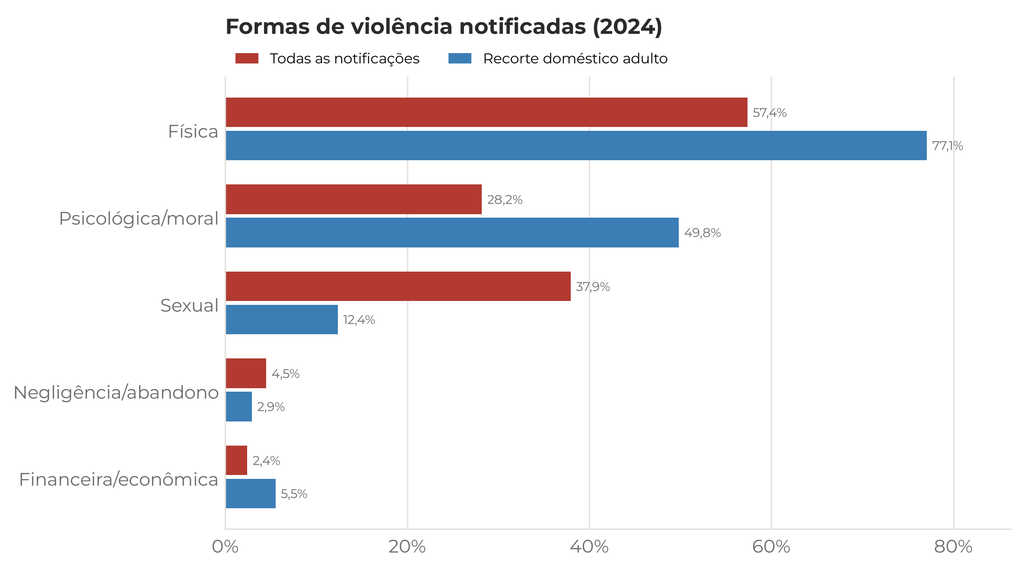

Figura 14: Formas de violência no total de notificações e no recorte doméstico adulto (% das respostas válidas).

No total, a violência física aparece em 57,4% das notificações, a sexual em 37,9% e a psicológica/moral em 28,2%. Em 24,5% há duas ou mais formas simultâneas. O perfil depende da idade:

- **Violência sexual.** Predomina na infância e na adolescência: está em 75% das notificações de meninas de 10 a 14 anos e em 62% das de 0 a 9 anos, contra 26% entre 30 e 39 anos. Metade das vítimas de violência sexual (50%) tem menos de 18 anos, e o estupro é o tipo registrado em 95,6% desses casos.
- **Violência física.** É a forma dominante na vida adulta (70,4% das notificações de maiores de 18 anos, contra 25,3% das de menores). No recorte doméstico adulto, chega a 77,1%, e a psicológica/moral a 49,8%, perfil próximo do registrado pela PMDF.

Quanto ao meio de agressão, predominam a força corporal ou espancamento (67,8%) e a ameaça (24,7%). Objeto perfurocortante aparece em 8,0% e arma de fogo em 1,0% das respostas válidas.

## 8.6 Autor, vínculo e local

Tabela 6: Vínculo do autor com a vítima, segundo a idade da vítima (% das notificações de cada faixa)

| Vínculo | Menos de 18 anos | 18 anos ou mais |
| --- | --- | --- |
| Parceiro ou ex-parceiro íntimo | 8,5% | 42,6% |
| Familiar | 40,9% | 8,6% |
| Conhecido(a) | 30,4% | 14,7% |
| Desconhecido(a) | 9,4% | 21,2% |
| Outro | 2,9% | 3,0% |
| Não informado | 8,0% | 9,8% |

O vínculo com o autor também muda com a idade. Entre as adultas, o parceiro ou ex-parceiro íntimo é o autor em 42,6% das notificações; entre as menores de 18 anos, predominam familiares (40,9%) e conhecidos (30,4%). O autor é do sexo masculino em 85,3% das respostas válidas.

- **Local.** A residência é o local de 69,8% das ocorrências com local informado, e a via pública de 14,0%.
- **Violência de repetição.** 57,4% das notificações com resposta válida informam que a violência já havia ocorrido antes (36,0% ignorado ou vazio). Ao contrário da repetição por endereço da PMDF, essa medida refere-se à própria vítima.
- **Álcool.** Houve suspeita de uso de álcool pelo autor em 49,0% das respostas válidas, mas o campo é ignorado em 43,1% das notificações.
- **Motivação.** Quando informada, a motivação é o sexismo em 69,0% dos casos.

Após a notificação, 83,2% das vítimas foram encaminhadas a outro serviço da rede de saúde. Os encaminhamentos para fora dela são menos frequentes: Conselho Tutelar (12,1%), Delegacia da Mulher (11,3%), outras delegacias (9,8%) e atendimento especializado à mulher (10,5%).

## 8.7 Associações

Assim como o tamanho do histórico na PMDF, a idade é o principal fator de confusão no SINAN: a violência sexual concentra-se na infância e a física por parceiro na vida adulta. As razões de prevalência foram calculadas entre respostas válidas, brutas e ajustadas por faixa etária (Mantel-Haenszel).

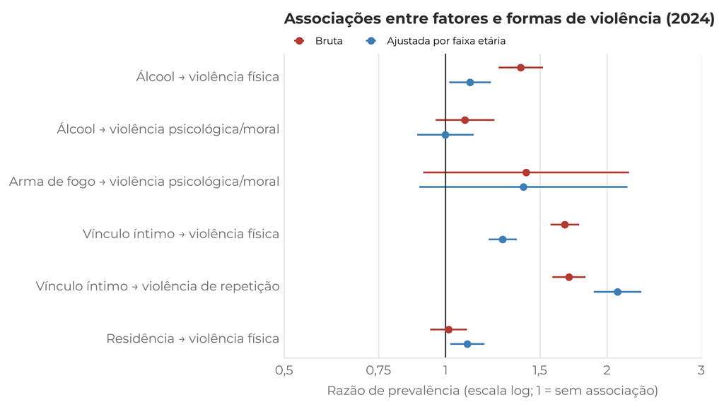

Figura 15: Razões de prevalência (IC 95%) brutas e ajustadas por faixa etária, SINAN.

Tabela 7: Razões de prevalência brutas e ajustadas por faixa etária, SINAN

| Associação | RP bruta (IC 95%) | RP ajustada (IC 95%) | n |
| --- | --- | --- | --- |
| Álcool → violência física | 1,38 (1,26–1,52) | 1,11 (1,02–1,22) | 1.763 |
| Álcool → violência psicológica/moral | 1,09 (0,96–1,23) | 1,00 (0,89–1,13) | 1.761 |
| Arma de fogo → violência psicológica/moral | 1,41 (0,91–2,20) | 1,40 (0,89–2,18) | 2.999 |
| Vínculo íntimo → violência física | 1,67 (1,57–1,78) | 1,28 (1,20–1,36) | 2.812 |
| Vínculo íntimo → violência de repetição | 1,70 (1,58–1,82) | 2,09 (1,89–2,32) | 1.928 |
| Residência → violência física | 1,01 (0,94–1,10) | 1,10 (1,02–1,18) | 2.529 |

- **Álcool e violência física.** A associação bruta (RP = 1,38; IC 95%: 1,26–1,52) cai após o ajuste por idade (RP = 1,11; IC 95%: 1,02–1,22), valor próximo do 1,17 encontrado por Bandiera-Paiva et al. (2026) com o SINAN de São Paulo. A estimativa ajustada da PMDF, também próxima de 1, aponta na mesma direção. Com a violência psicológica/moral, a associação desaparece (RP ajustada = 1,00; IC 95%: 0,89–1,13).
- **Vínculo íntimo.** Ser agredida por parceiro ou ex-parceiro associa-se à violência física (RP ajustada = 1,28; IC 95%: 1,20–1,36) e, sobretudo, à violência de repetição (RP ajustada = 2,09; IC 95%: 1,89–2,32). É a associação mais forte da base, coerente com o caráter cíclico da violência por parceiro.
- **Arma de fogo e violência psicológica/moral.** A estimativa (RP ajustada = 1,40; IC 95%: 0,89–2,18) tem intervalo amplo, por haver poucos casos com arma de fogo, e não permite conclusão.

Como na PMDF, as associações são transversais e não autorizam leitura causal.

## 8.8 Síntese do SINAN

- **Perfil distinto da PMDF.** O SINAN reúne violência sexual contra meninas e violência física contra mulheres adultas. Só o recorte doméstico adulto (36,5% das notificações) é diretamente comparável aos atendimentos policiais.
- **Padrão temporal convergente.** Fins de semana e noites concentram a violência nas duas fontes, o que reforça a leitura de que o tempo de convívio eleva o risco.
- **Repetição associada ao vínculo íntimo.** Mais da metade das notificações informam violência anterior, e o vínculo íntimo praticamente dobra essa proporção após o ajuste por idade.
- **Limites da fonte.** A notificação tardia, as datas imputadas e o alto percentual de ignorado em campos de contexto exigem cautela, sobretudo no ano mais recente.

# 9 Integração complementar: SINAN × PMDF

O SINAN registra notificações de violência feitas por serviços de saúde. A PMDF registra atendimentos policiais. Um mesmo episódio pode estar nas duas fontes, em uma ou em nenhuma. As bases não compartilham identificador de pessoa, por isso a comparação é **apenas agregada** (por mês e por indicador), sem nenhum cruzamento caso a caso. Em 2024, o recorte do SINAN (mulheres, ocorrência no DF, violência não autoprovocada) somou 3.112 notificações, frente a 12.123 ocorrências da PMDF.

Tabela 8: Composição dos indicadores na PMDF e no SINAN (2024)

| Indicador | PMDF (% das ocorrências) | SINAN (% das respostas válidas) | SINAN: ignorado ou vazio (n) |
| --- | --- | --- | --- |
| Violência física | 40,3% | 57,4% | 13 |
| Violência psicológica | 34,6% | 28,2% | 27 |
| Violência sexual | 0,4% | 38,0% | 26 |
| Uso de arma de fogo | 2,4% | 1,0% | 98 |
| Uso de objeto perfurocortante | 8,0% | 8,0% | 96 |
| Suspeita de uso de álcool pelo autor | 15,9% | 49,0% | 1.341 |

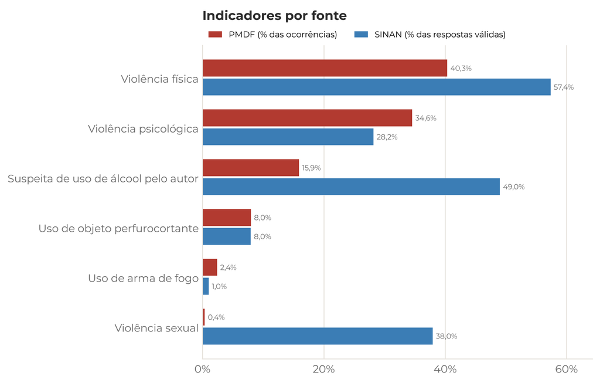

Figura 16: Composição dos indicadores nas duas fontes (2024). As bases não são diretamente equivalentes.

As diferenças refletem o que cada canal registra, e não a prevalência na população. A violência sexual aparece em 38,0% das notificações válidas do SINAN e em 0,4% das ocorrências da PMDF. A violência psicológica, ao contrário, é mais registrada pela PMDF. O álcool mostra a diferença entre campo estruturado e texto livre: no SINAN, a suspeita de uso pelo autor é uma pergunta da ficha e aparece em 49,0% das respostas válidas; na PMDF, depende de o policial mencioná-lo e aparece em 15,9%. A flag textual provavelmente subestima a presença do álcool.

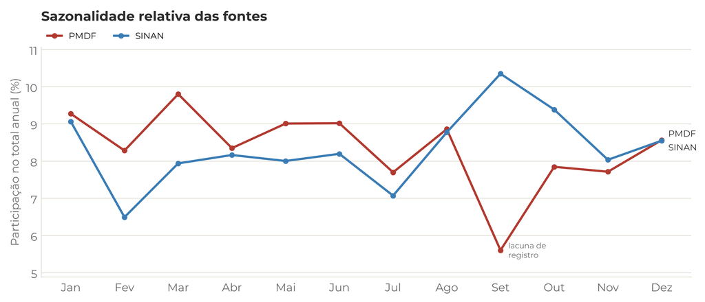

Figura 17: Participação de cada mês no total anual de cada fonte (2024). Setembro da PMDF está afetado pela lacuna de registro.

Os picos não coincidem: março na PMDF e setembro no SINAN. A correlação mensal de volume foi −0,40 (p = 0,192), mas esse valor é **dominado pela lacuna de registro de setembro**. Sem setembro, a correlação passa a 0,20 (p = 0,554). Nas defasagens de −3 a +3 meses, nenhum dos 49 testes permaneceu significativo após o ajuste de Benjamini-Hochberg. Com 12 observações mensais, não há evidência de que uma fonte anteceda a outra.

Tabela 9: Métricas de reiteração em cada fonte (conceitos não comparáveis)

| Fonte | Métrica | Casos | Base válida | Percentual |
| --- | --- | --- | --- | --- |
| PMDF | repetição espacial de endereço | 1.650 | 12.123 | 13,6% |
| SINAN | histórico de violência relatado | 1.143 | 1.991 | 57,4% |

A PMDF mede a repetição de endereço; o SINAN, o histórico de violência informado na notificação. As métricas não se referem à mesma pessoa nem à mesma unidade e, por isso, não foram correlacionadas.

# 10 Limitações

1. **Registros, não prevalência.** A base reflete a demanda que chegou à PMDF em um único ano, com a ocorrência como unidade.
2. **Indicadores textuais.** As flags dependem do que o policial escreveu e da cobertura dos dicionários. Ainda não há amostra anotada manualmente para estimar precisão e sensibilidade das regras, e o tamanho da narrativa enviesa as associações brutas.
3. **Lacuna de registro.** De 06/09 a 16/09/2024 não há registros no sistema. A causa precisa ser confirmada com a PMDF.
4. **Georreferenciamento.** Cerca de metade das ocorrências não tem coordenada utilizável, com forte desigualdade entre RAs.
5. **Ausência de população.** Sem denominadores populacionais por RA, comparações territoriais são de volume, não de risco.
6. **SINAN.** Notificação tardia (último ano subestimado), datas de ocorrência imputadas no dia 1, hora pouco preenchida e alto percentual de ignorado em campos como álcool e motivação.
7. **Desfecho.** Não foi identificado em 27,5% das narrativas.

# 11 Conclusões e próximos passos

- **A demanda tem padrão temporal claro.** Concentra-se nas noites e nos fins de semana e cresce nos feriados que caem em dias úteis. É informação diretamente utilizável no planejamento de escalas.
- **A violência registrada é múltipla, com predomínio da física e da psicológica.** A violência sexual é quase ausente nos registros policiais e aparece no SINAN, o que reforça a complementaridade dos canais.
- **Associações extraídas de texto precisam de ajuste pelo tamanho da narrativa.** Sem ele, o álcool parece associado a todas as formas de violência. Ajustada, a associação com a violência física é próxima de nula, enquanto as com violência psicológica e moral persistem.
- **A grade de 500 m ainda não serve como base preditiva.** Ela organiza a demanda espacialmente, mas a cobertura desigual de GPS a enviesa. Qualquer modelo deve partir das contagens por RA, que são completas, e usar a grade só nas RAs com boa cobertura.

**Próximos passos priorizados:**

1. Confirmar com a PMDF a lacuna de setembro e o significado da coordenada-padrão.
2. Anotar manualmente uma amostra de históricos para medir a precisão das flags.
3. Obter a população por RA (PDAD/IPEDF) para calcular taxas.
4. Solicitar 2022–2023 para modelar a demanda por RA e semana com mais de um ciclo anual.
5. Obter o tempo de resposta por ocorrência para avaliar as células de alta demanda distantes dos batalhões.

# Referências

BANDIERA-PAIVA, P. et al. Uso de inteligência artificial para análise da violência contra mulheres em São Paulo. **Revista de Saúde Pública**, v. 60, e28, 2026.

BRASIL. Lei nº 11.340, de 7 de agosto de 2006 (Lei Maria da Penha).

BRASIL. Ministério da Saúde. **Viva**: instrutivo de notificação de violência interpessoal e autoprovocada. 2. ed. Brasília: Ministério da Saúde, 2016.

FARRELL, G.; PEASE, K. **Once bitten, twice bitten**: repeat victimisation and its implications for crime prevention. London: Home Office, 1993.

KUMAR, S. et al. Domestic abuse hot spots: a longitudinal, place-based analysis of 13 years of initial reports to the police. **Policing: A Journal of Policy and Practice**, v. 18, paae056, 2024.